# Titanic-ML

Gabriel Odreman

20/4/2021

## ———————————————————————

##### Página del Ejemplo y Data

###### https://www.europeanvalley.es/noticias/analizamos-el-titanic-con-r/

###### https://europeanvalley.es/resources/titanic/titanicdf.csv

```r
library(tidyverse)
```

#### Analizar el Titanic con Maching Learning de R

##### Análisis exploratorio de los datos

###### Antes de entrenar un modelo predictivo, o incluso antes de realizar cualquier cálculo con un nuevo conjunto de datos, es muy importante realizar una exploración descriptiva de los mismos. Este proceso permite entender mejor que información contiene cada variable, así como detectar posibles errores. Algunos ejemplos frecuentes son:

###### • Que una columna se haya almacenado con el tipo incorrecto: una variable numérica está siendo reconocida como texto.

###### • Que una variable contenga valores que no tienen sentido: para indicar que no se dispone de la altura de una persona se introduce el valor cero o un espacio en blanco. No existe nadie cuya altura sea cero.

###### • Que en una variable de tipo numérico se haya introducido una palabra en lugar de un número.

```r
titanicdf <- read.csv("D:/d/2-ESTUDIO/R/MachinLearnig-Ejemplos/titanicdf.csv")

View(titanicdf) # Visualizamos los datos para realizar los análisis iniciales
colSums(is.na(titanicdf)) # Verificamos las columnas que tienen datos nulos
```

```
##           X PassengerId    Survived      Pclass        Name         Sex
##           0           0           0           0           0           0
##         Age       SibSp       Parch      Ticket        Fare       Cabin
##         263           0           0           0           1           0
##    Embarked
##           0
```

##### Nombre de las Variables

###### • PassengerId: identificador único del pasajero.

###### • Survived: si el pasajero sobrevivió al naufragio, codificada como 0 (no) y 1 (si). Esta es la variable respuesta que interesa predecir.

###### • Pclass: clase a la que pertenecía el pasajero: 1, 2 o 3.

###### • Name: nombre del pasajero.

###### • Sex: sexo del pasajero.

###### • Age: edad del pasajero.

###### • SibSp: número de hermanos, hermanas, hermanastros o hermanastras en el barco.

###### • Parch: número de padres e hijos en el barco.

###### • Ticket: identificador del billete.

###### • Fare: precio pagado por el billete.

###### • Cabin: identificador del camarote asignado al pasajero.

###### • Embarked: puerto en el que embarcó el pasajero.

##### Tipo de variables

###### Una de las primeras comprobaciones que hay que hacer tras cargar los datos, es verificar que cada variable se ha almacenado con el tipo de valor que le corresponde, es decir, que las variables numéricas sean números y las cualitativas factor, character o booleanas. En el lenguaje de programación R, cuando la variable es cualitativa, conviene almacenarla con el tipo factor.

```r
glimpse(titanicdf) # Para visualizar los tipos de variables o la función str()
```

```
## Rows: 1,309
## Columns: 13
## $ X           <int> 1, 2, 3, 4, 5, 6, 7, 8, 9, 10, 11, 12, 13, 14, 15, 16, ...
## $ PassengerId <int> 1, 2, 3, 4, 5, 6, 7, 8, 9, 10, 11, 12, 13, 14, 15, 16, ...
## $ Survived    <int> 0, 1, 1, 1, 0, 0, 0, 0, 1, 1, 1, 1, 0, 0, 0, 1, 0, 1, 0...
## $ Pclass      <int> 3, 1, 3, 1, 3, 3, 1, 3, 3, 2, 3, 1, 3, 3, 3, 2, 3, 2, 3...
## $ Name        <chr> "Braund, Mr. Owen Harris", "Cumings, Mrs. John Bradley ...
## $ Sex         <chr> "male", "female", "female", "female", "male", "male", "...
## $ Age         <dbl> 22, 38, 26, 35, 35, NA, 54, 2, 27, 14, 4, 58, 20, 39, 1...
## $ SibSp       <int> 1, 1, 0, 1, 0, 0, 0, 3, 0, 1, 1, 0, 0, 1, 0, 0, 4, 0, 1...
## $ Parch       <int> 0, 0, 0, 0, 0, 0, 0, 1, 2, 0, 1, 0, 0, 5, 0, 0, 1, 0, 0...
## $ Ticket      <chr> "A/5 21171", "PC 17599", "STON/O2. 3101282", "113803", ...
## $ Fare        <dbl> 7.2500, 71.2833, 7.9250, 53.1000, 8.0500, 8.4583, 51.86...
## $ Cabin       <chr> "", "C85", "", "C123", "", "", "E46", "", "", "", "G6",...
## $ Embarked    <chr> "S", "C", "S", "S", "S", "Q", "S", "S", "S", "C", "S", ...
```

##### Análisis de las Varibles

```r
data.frame(unclass(summary(titanicdf)), check.names = FALSE, stringsAsFactors = FALSE) # Visualizamos todos los detalle de los datos
```

```
##                  X    PassengerId         Survived          Pclass
## X   Min.   :   1   Min.   :   1   Min.   :0.0000   Min.   :1.000
## X.1 1st Qu.: 328   1st Qu.: 328   1st Qu.:0.0000   1st Qu.:2.000
## X.2 Median : 655   Median : 655   Median :0.0000   Median :3.000
## X.3 Mean   : 655   Mean   : 655   Mean   :0.3774   Mean   :2.295
## X.4 3rd Qu.: 982   3rd Qu.: 982   3rd Qu.:1.0000   3rd Qu.:3.000
## X.5 Max.   :1309   Max.   :1309   Max.   :1.0000   Max.   :3.000
## X.6           <NA>           <NA>             <NA>            <NA>
##                   Name                Sex             Age            SibSp
## X   Length:1309        Length:1309        Min.   : 0.17   Min.   :0.0000
## X.1 Class :character   Class :character   1st Qu.:21.00   1st Qu.:0.0000
## X.2 Mode  :character   Mode  :character   Median :28.00   Median :0.0000
## X.3               <NA>               <NA> Mean   :29.88   Mean   :0.4989
## X.4               <NA>               <NA> 3rd Qu.:39.00   3rd Qu.:1.0000
## X.5               <NA>               <NA> Max.   :80.00   Max.   :8.0000
## X.6               <NA>               <NA>   NA's   :263               <NA>
##               Parch             Ticket              Fare              Cabin
## X   Min.   :0.000   Length:1309        Min.   :  0.000   Length:1309
## X.1 1st Qu.:0.000   Class :character   1st Qu.:  7.896   Class :character
## X.2 Median :0.000   Mode  :character   Median : 14.454   Mode  :character
## X.3 Mean   :0.385                 <NA> Mean   : 33.295                 <NA>
## X.4 3rd Qu.:0.000                 <NA> 3rd Qu.: 31.275                 <NA>
## X.5 Max.   :9.000                 <NA> Max.   :512.329                 <NA>
## X.6            <NA>               <NA>       NA's   :1                 <NA>
##               Embarked
## X   Length:1309
## X.1 Class :character
## X.2 Mode  :character
## X.3               <NA>
## X.4               <NA>
## X.5               <NA>
## X.6               <NA>
```

###### Los valores de Survived podrian cambairse a factor para evitar determinar Min , Max y Medias

##### Modificación de los Datos.

###### El campo edad tiene muchos valores nulos para ello utilizamos la media de los valores de la edad 29,88. la media es con decimales convertimos todo a entero

```r
titanicdf[is.na(titanicdf$Age), "Age"] <- mean(titanicdf$Age, na.rm=T)
titanicdf$Age <- as.integer(titanicdf$Age)
```

###### Valores NUlos

```r
colSums(is.na(titanicdf)) # Para verificar los valores nulos por columnas
```

```
##           X PassengerId    Survived      Pclass        Name         Sex
##           0           0           0           0           0           0
##         Age       SibSp       Parch      Ticket        Fare       Cabin
##           0           0           0           0           1           0
##    Embarked
##           0
```

###### Eliminamos las columnas que no necesitamos Cabin y Ticket

```r
titanicdf$Cabin <- NULL
titanicdf$Ticket <- NULL
```

###### Como existen pocos nulos Fare podemos eliminar esa linea.

```r
titanicdf=na.omit(titanicdf)
```

##### Creacion de variable Dummies

###### El paquete fastDummies esta diseñado específicamente para convertir variables categóricas en dummies.

###### https://rpubs.com/jboscomendoza/vairables_dummy_con_r

```r
library(fastDummies)
```

###### Podemos crear variables dummy con la función dummy_cols. Damos como argumentos un data frame y el nombre de las columnas que queremos convertir a dummy. Si no damos nombres de columna, convertirá todas las que sean de tipo carácter o factor.

```r
titanicdf <- dummy_cols(titanicdf,  select_columns = c("Sex", "Embarked"))
```

###### Esta función nos devuelve un data frame que conserva las variables originales, así que tenemos que usar select para quitarlas, si así lo deseamos.

###### Modificamos Sex por Sex_female y Borramos Sex_Male y Sex_Female

```r
titanicdf$Sex <-titanicdf$Sex_female
titanicdf$Sex_female <- NULL
titanicdf$Sex_male <- NULL
titanicdf$Embarked <- NULL
titanicdf$Embarked_ <- NULL
```

##### Machine Learning, Análisis de los Datos según un modelo

###### Una vez que tenemos los datos ya ordenados, tenemos que crear nuestro modelos predictivo.

###### Para ellos creamos dos tipo de Datos, Train ( para el modelo) y Test (para comparar los datos).

```r
train <- titanicdf[1:890, ]  # Valores para aprendizaje del modelo
test  <- titanicdf[891:1308, ] # Valores para comparar con el modelo.
```

###### El paquete caret, desarrollado por Max Kuhn, es una interfaz que unifica bajo un único marco cientos de funciones de distintos paquetes, facilitando en gran medida todas las etapas de de preprocesado, entrenamiento, optimización y validación de modelos predictivos.

```r
library(caret) # Librería para Modelado de Datos
```

##### Modelo Sigmoide (graficamos la curva para ejemplificar como vamos a modelar los datos)

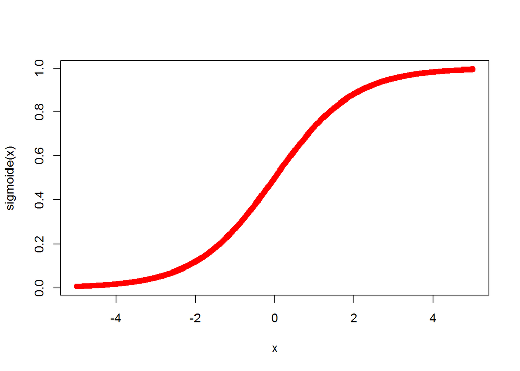

```r
sigmoide = function(x){1/(1+exp(-x))}
x <- seq (-5,5,0.01)
plot(x,sigmoide(x),col="red")
```

##### Crear Modelo

###### Podemos utilizar diferentes modelos en nuestro caso usamos binomial

###### Ver referencia “https://rpubs.com/JessicaP/459130”

```r
RL_titanic <- glm(Survived~ Pclass + Sex + Age + SibSp + Fare + Embarked_C + Embarked_Q + Embarked_S,data= train, family = binomial)
```

```r
summary(RL_titanic)
```

```
##
## Call:
## glm(formula = Survived ~ Pclass + Sex + Age + SibSp + Fare +
##     Embarked_C + Embarked_Q + Embarked_S, family = binomial,
##     data = train)
##
## Deviance Residuals:
##     Min       1Q   Median       3Q      Max
## -2.6681  -0.6043  -0.4199   0.6366   2.4491
##
## Coefficients:
##               Estimate Std. Error z value Pr(>|z|)
## (Intercept)  14.905337 610.564029   0.024  0.98052
## Pclass       -1.112255   0.142231  -7.820 5.28e-15 ***
## Sex           2.684628   0.195657  13.721  < 2e-16 ***
## Age          -0.039422   0.007819  -5.042 4.62e-07 ***
## SibSp        -0.346856   0.105954  -3.274  0.00106 **
## Fare          0.001541   0.002276   0.677  0.49857
## Embarked_C  -12.336038 610.563839  -0.020  0.98388
## Embarked_Q  -12.344918 610.563893  -0.020  0.98387
## Embarked_S  -12.755055 610.563822  -0.021  0.98333
## ---
## Signif. codes:  0 '***' 0.001 '**' 0.01 '*' 0.05 '.' 0.1 ' ' 1
##
## (Dispersion parameter for binomial family taken to be 1)
##
##     Null deviance: 1185.69  on 889  degrees of freedom
## Residual deviance:  784.77  on 881  degrees of freedom
## AIC: 802.77
##
## Number of Fisher Scoring iterations: 13
```

###### Los datos de Embarked dan un valor de Pr muy alto por lo cual no son representativos en la evalucíon. Pr debe ser menor a 0.5

##### Evaluamos el Modelo con los datos de Test

```r
predictions <- predict (RL_titanic, test)
View(predictions)
```

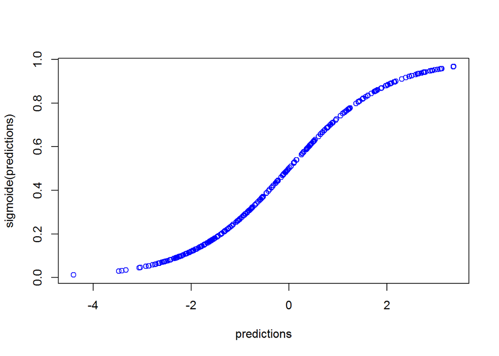

```r
plot (predictions,sigmoide(predictions),col="blue")
```

###### Las predicciones tienes valores negativos y positivos, los modificamos haciendo que todos aquellos que sean mayores a 0.5 se conviertan en 1 y los que no cumplan serán 0

```r
mod_pred <- ifelse(predictions > 0.5, 1, 0)
View(mod_pred)
```

###### Convertimos los valores en factores para compararlos y utilizamos la función confusionMatrix para comparar los valores.

```r
mod_pred <- factor(mod_pred)
test$Survived <- factor(test$Survived)
confusionMatrix(mod_pred, test$Survived)
```

```
## Confusion Matrix and Statistics
##
##           Reference
## Prediction   0   1
##          0 261  32
##          1   5 120
##
##                Accuracy : 0.9115
##                  95% CI : (0.8801, 0.9369)
##     No Information Rate : 0.6364
##     P-Value [Acc > NIR] : < 2.2e-16
##
##                   Kappa : 0.8012
##
##  Mcnemar's Test P-Value : 1.917e-05
##
##             Sensitivity : 0.9812
##             Specificity : 0.7895
##          Pos Pred Value : 0.8908
##          Neg Pred Value : 0.9600
##              Prevalence : 0.6364
##          Detection Rate : 0.6244
##    Detection Prevalence : 0.7010
##       Balanced Accuracy : 0.8853
##
##        'Positive' Class : 0
##
```

###### Al comparar los valores tenemos de los Pasajeros con valor 0 que son los que no sobrevivieron, concuerdan con el test en 261 y hay 32 que no. De los valores con 1 concuerdan 120 y 5 que no. Hay una representatividad del 91.15 %

##### Modelo de Árbol de Decisión

```r
library(rpart)
library(rpart.plot)
tree_titanic <- rpart(Survived~ Pclass + Sex + Age + SibSp + Fare + Embarked_C + Embarked_Q + Embarked_S,data= train)
pred_tree <- predict(tree_titanic,test)
View(pred_tree)
```

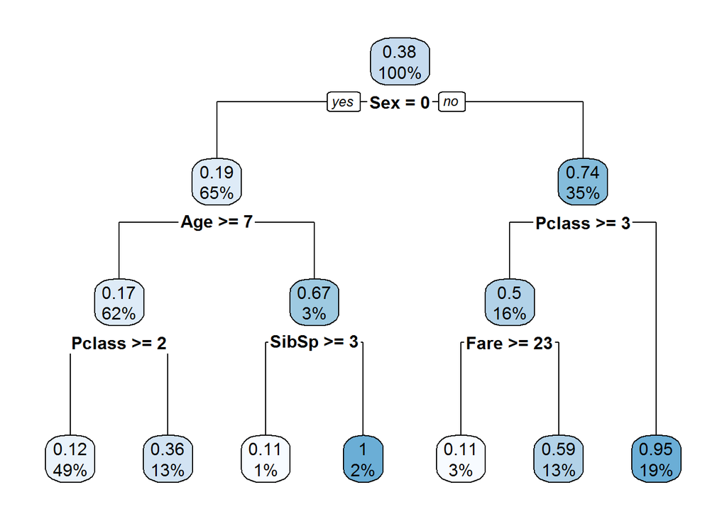

```r
pred_tree <- ifelse(pred_tree > 0.5,1,0)
rpart.plot(tree_titanic)
```

###### Los datos Embarked no son relevantes para los análisis.

```r
pred_tree <- factor(pred_tree)
test$Survived <- factor(test$Survived)
confusionMatrix(pred_tree,test$Survived)
```

```
## Confusion Matrix and Statistics
##
##           Reference
## Prediction   0   1
##          0 260   6
##          1   6 146
##
##                Accuracy : 0.9713
##                  95% CI : (0.9504, 0.9851)
##     No Information Rate : 0.6364
##     P-Value [Acc > NIR] : <2e-16
##
##                   Kappa : 0.938
##
##  Mcnemar's Test P-Value : 1
##
##             Sensitivity : 0.9774
##             Specificity : 0.9605
##          Pos Pred Value : 0.9774
##          Neg Pred Value : 0.9605
##              Prevalence : 0.6364
##          Detection Rate : 0.6220
##    Detection Prevalence : 0.6364
##       Balanced Accuracy : 0.9690
##
##        'Positive' Class : 0
##
```

## —————————————————————————

##### Conclusiones.

###### El modelo de Arbol nos da una certidumbre de 97.13 % , para lograr una mejor aproximación se podrian probar con otros modelos y evaluar sólo los parametro significativos.